# Test a Perceptual Phenomenon Project

## Background Information

In a Stroop task, participants are presented with a list of words, with each word displayed in a color of ink. The participant’s task is to say out loud the color of the ink in which the word is printed. The task has two conditions: a congruent words condition, and an incongruent words condition. In the congruent words condition, the words being displayed are color words whose names match the colors in which they are printed: for example RED, BLUE. In the incongruent words condition, the words displayed are color words whose names do not match the colors in which they are printed: for example PURPLE, ORANGE. In each case, we measure the time it takes to name the ink colors in equally-sized lists. Each participant will go through and record a time from each condition.

# Analysis

**Ques1. What is our independent variable? What is our dependent variable?**

There are two variables in the stroop task i.e independent variable and dependent variable. They are described below:  
**1. Independent variable:**  
A variable is said to be independent if it can be manipulated by the researcher and experimenter .It has direct  
influence on the dependent variable. the independent variable in the experiment is congruent words and  
incongruent words condition.  
**2. Dependent variable:**  
A variable is said to be dependent which is measured in the experiment. Dependent variable is the time taken to read all  
the ink color.for example: I took 14.63 seconds to read all the ink colored words in first time . Then in second time , I took  
28.6 seconds.

**Ques2. What is an appropriate set of hypotheses for this task? What kind of statistical test do you expect to perform? Justify your choices.**

The appropriate set of hypothesis are:  
**1.Null hypothesis :**  
there is no approximate difference in time taken to read the congruent task  
and time taken to read the incongruent task.

let us depict i by incongruent task and c by congruent task.  
$ H_0 $ ( Null Hypothesis ) : (Popu Mean)<sub>incongruent</sub> = (Popu Mean)<sub>congruent</sub> OR $\mu_i = \mu_c$

**2.Alternative hypothesis :**  
there is approximate difference in time taken to read the congruent task  
and time taken to read the incongruent task.

let us depict i by incongruent task and c by congruent task.  
$ H_1 $ ( Alternative Hypothesis ) : (Popu Mean)<sub>incongruent</sub> ≠ (Popu Mean)<sub>congruent</sub> OR $ \mu_i$ ≠ $\mu_c $  
Where

- $ \mu_i$ = Mean time to speak the ink color for incongruent words.
- $ \mu_c$ = Mean time to speak the ink color for congruent words.

I will depict my statistical test by using t-tailed test. the t-tailed tests tells us that there are statistically significant differences between these means.

**Reason for selecting t - tailed test :**

1. there are less than 30 population sample size so we are using t tailed tests.
2. we dont have direction so we used t-tailed test.

**Ques3. Report some descriptive statistics regarding this dataset.Include at least one measure of central tendency and at least one measure of variability.**

```python
import math
import numpy as np
import pandas as pd
```

```python
data = pd.read_csv("stroopdata1.csv")
data
```

|  | Congruent | Incongruent |
| --- | --- | --- |
| 0 | 12.079 | 19.278 |
| 1 | 16.791 | 18.741 |
| 2 | 9.564 | 21.214 |
| 3 | 8.630 | 15.687 |
| 4 | 14.669 | 22.803 |
| 5 | 12.238 | 20.878 |
| 6 | 14.692 | 24.572 |
| 7 | 8.987 | 17.394 |
| 8 | 9.401 | 20.762 |
| 9 | 14.480 | 26.282 |
| 10 | 22.328 | 24.524 |
| 11 | 15.298 | 18.644 |
| 12 | 15.073 | 17.510 |
| 13 | 16.929 | 20.330 |
| 14 | 18.200 | 35.255 |
| 15 | 12.130 | 22.158 |
| 16 | 18.495 | 25.139 |
| 17 | 10.639 | 20.429 |
| 18 | 11.344 | 17.425 |
| 19 | 12.369 | 34.288 |
| 20 | 12.944 | 23.894 |
| 21 | 14.233 | 17.960 |
| 22 | 19.710 | 22.058 |
| 23 | 16.004 | 21.157 |

```python
congruent_mean = data['Congruent'].mean()
incongruent_mean = data['Incongruent'].mean()

#Find the median
congruent_median = data['Congruent'].median()
incongruent_median = data['Incongruent'].median()

#Find the standard deviation
congruent_std = data['Congruent'].std()
incongruent_std = data['Incongruent'].std()

#print mean,median and standard deviation in a table
ls = [[int(24),int(24)],[c_mean,i_mean],[c_median,i_median],[c_std,i_std]]
detail = pd.DataFrame(ls,index=['Sample Size','Mean','Median','Standard Deviation'],columns=['Congruent','Incongruent'])
detail
```

[output not shown]

```python
data.describe()
```

|  | Congruent | Incongruent |
| --- | --- | --- |
| count | 24.000000 | 24.000000 |
| mean | 14.051125 | 22.015917 |
| std | 3.559358 | 4.797057 |
| min | 8.630000 | 15.687000 |
| 25% | 11.895250 | 18.716750 |
| 50% | 14.356500 | 21.017500 |
| 75% | 16.200750 | 24.051500 |
| max | 22.328000 | 35.255000 |

Ques4. Provide one or two visualizations that show the distribution of the sample data. Write one or two sentences  
noting what you observe about the plot or plots.

```python
import matplotlib.pyplot as plt
%matplotlib inline
```

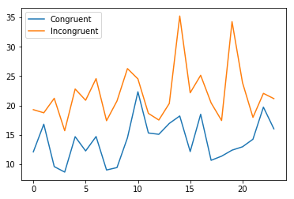

```python
data.plot()
```

```python
conarr = np.array(data.Congruent)
```

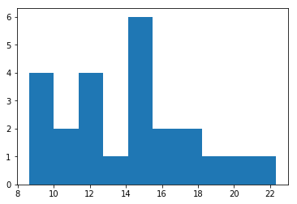

```python
plt.hist(conarr)
```

```python
inconarr = np.array(data.Incongruent)
```

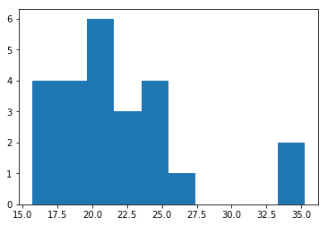

```python
plt.hist(inconarr)
```

We can observe from the histogram that average completion time of incongruent data is higher than  
average completion time of congruent data.

Ques5. Now, perform the statistical test and report your results. What is your confidence level and your critical statistic  
value? Do you reject the null hypothesis or fail to reject it? Come to a conclusion in terms of the experiment task. Did  
the results match up with your expectations?

```python
from scipy import stats
print("t-critical value is: ",round(stats.t.ppf(0.95,23),3))
```

```
t-critical value is:  1.714
```

```python
stats.ttest_rel(data['Congruent'], data['Incongruent'])
```

```
Ttest_relResult(statistic=-8.020706944109957, pvalue=4.103000585711178e-08)
```

**List of websites,books and other resources**

- https://towardsdatascience.com/inferential-statistics-series-t-test-using-numpy-2718f8f9bf2f
- https://scientificallysound.org/2017/05/16/independent-t-test-python/
- Business Statistics by J.K Sharma